# Final Project

```r
library(tidyverse)
library(lubridate)
library(readr)
library("ggplot2")
library("dplyr")
library(xts)
library("lubridate")
library("RColorBrewer")
library("ggthemes")
library(gridExtra)
library(corrplot)
library(fmsb)

data <- read_csv("./Project_1_data.csv")

for (column in colnames(data)) {
  num_distinct_values <- length(unique(data[[column]]))
  print(paste(column, ":", num_distinct_values, "distinct values"))
}
```

```
## [1] "Gender : 2 distinct values"
## [1] "EthnicGroup : 6 distinct values"
## [1] "ParentEduc : 7 distinct values"
## [1] "LunchType : 2 distinct values"
## [1] "TestPrep : 3 distinct values"
## [1] "ParentMaritalStatus : 5 distinct values"
## [1] "PracticeSport : 4 distinct values"
## [1] "IsFirstChild : 3 distinct values"
## [1] "NrSiblings : 9 distinct values"
## [1] "TransportMeans : 3 distinct values"
## [1] "WklyStudyHours : 4 distinct values"
## [1] "MathScore : 78 distinct values"
## [1] "ReadingScore : 75 distinct values"
## [1] "WritingScore : 78 distinct values"
```

```r
library(ggplot2)
```

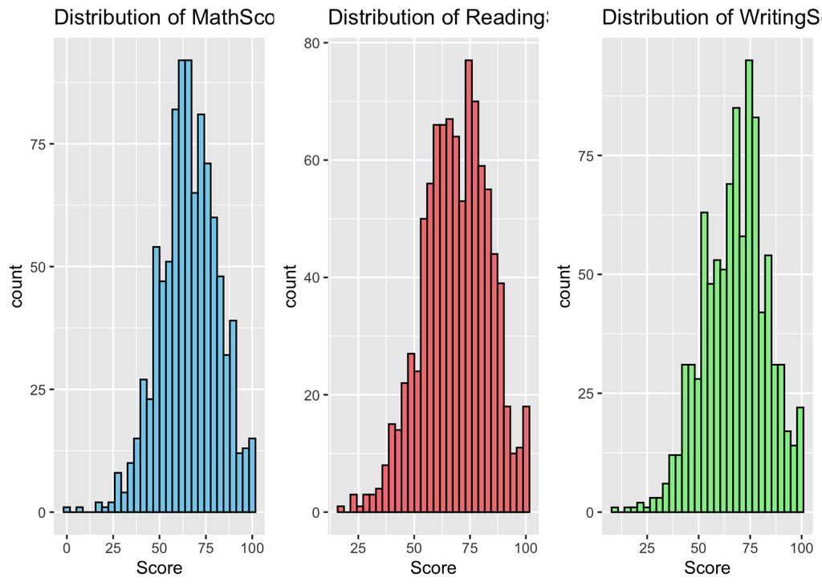

```r
# Create a ggplot for the distribution of MathScore
plot_math <- ggplot(data, aes(x = MathScore)) +
  geom_histogram(fill = "skyblue", color = "black", bins = 30) +
  labs(title = "Distribution of MathScore", x = "Score")

# Create a ggplot for the distribution of ReadingScore
plot_reading <- ggplot(data, aes(x = ReadingScore)) +
  geom_histogram(fill = "lightcoral", color = "black", bins = 30) +
  labs(title = "Distribution of ReadingScore", x = "Score")

# Create a ggplot for the distribution of WritingScore
plot_writing <- ggplot(data, aes(x = WritingScore)) +
  geom_histogram(fill = "lightgreen", color = "black", bins = 30) +
  labs(title = "Distribution of WritingScore", x = "Score")

grid.arrange(plot_math, plot_reading, plot_writing, ncol = 3)
```

```r
ggtitle("Distribution of the test scores")
```

```
## $title
## [1] "Distribution of the test scores"
##
## attr(,"class")
## [1] "labels"
```

To deal with NA values, we replaced every NA value with the most frequent value in each column.

```r
data_cleaned <- apply(data, 2, function(x) ifelse(is.na(x), names(sort(table(x), decreasing = TRUE)[1]), x))

null_val <- sum(is.na(data_cleaned))

if (null_val > 0) {
  print(paste('Try imputing again, there are', null_val, 'null values remaining in the dataset'))
} else {
  print('Congratulations! You have successfully imputed all the null values in the dataset.')
}
```

```
## [1] "Congratulations! You have successfully imputed all the null values in the dataset."
```

```r
data_cleaned <- data.frame(data_cleaned)

order_parent_educ_categories <- c('some high school', 'high school', "associate's degree", 'some college', "bachelor's degree", "master's degree")

order_ethnic_categories <- c('group A', 'group B', 'group C', 'group D', 'group E')

study_categories <- c('< 5', '5-10', '> 10')

data_cleaned <- data_cleaned %>%
  mutate(Gender = as.factor(Gender),
         MathScore = as.integer(MathScore),
         ReadingScore = as.integer(ReadingScore),
         WritingScore = as.integer(WritingScore),
         ParentEduc = factor(ParentEduc, levels = order_parent_educ_categories, ordered = TRUE),
         EthnicGroup = factor(EthnicGroup, levels = order_ethnic_categories, ordered = TRUE)) %>%
  mutate(ln_math = log(MathScore),
         ln_reading = log(ReadingScore),
         ln_writing = log(WritingScore))

model_1 <- lm(ReadingScore ~ LunchType, data = data_cleaned)
summary(model_1)
```

```
##
## Call:
## lm(formula = ReadingScore ~ LunchType, data = data_cleaned)
##
## Residuals:
##     Min      1Q  Median      3Q     Max
## -47.073  -9.154   0.600  10.600  35.927
##
## Coefficients:
##                   Estimate Std. Error t value Pr(>|t|)
## (Intercept)        64.0725     0.7909  81.015  < 2e-16 ***
## LunchTypestandard   7.3278     0.9803   7.475 1.76e-13 ***
## ---
## Signif. codes:  0 '***' 0.001 '**' 0.01 '*' 0.05 '.' 0.1 ' ' 1
##
## Residual standard error: 14.39 on 946 degrees of freedom
## Multiple R-squared:  0.05577,    Adjusted R-squared:  0.05477
## F-statistic: 55.87 on 1 and 946 DF,  p-value: 1.758e-13
```

```r
model_2 <- lm(ReadingScore ~ EthnicGroup, data = data_cleaned)
summary(model_2)
```

```
##
## Call:
## lm(formula = ReadingScore ~ EthnicGroup, data = data_cleaned)
##
## Residuals:
##     Min      1Q  Median      3Q     Max
## -51.152 -10.080   0.806  10.806  34.663
##
## Coefficients:
##               Estimate Std. Error t value Pr(>|t|)
## (Intercept)   68.74558    0.53790 127.803  < 2e-16 ***
## EthnicGroup.L  5.95373    1.40966   4.224 2.64e-05 ***
## EthnicGroup.Q  0.99246    1.26586   0.784    0.433
## EthnicGroup.C  0.51404    1.14426   0.449    0.653
## EthnicGroup^4 -0.08827    0.94231  -0.094    0.925
## ---
## Signif. codes:  0 '***' 0.001 '**' 0.01 '*' 0.05 '.' 0.1 ' ' 1
##
## Residual standard error: 14.67 on 943 degrees of freedom
## Multiple R-squared:  0.02149,    Adjusted R-squared:  0.01733
## F-statistic: 5.176 on 4 and 943 DF,  p-value: 0.0003972
```

```r
model_3 <- lm(ReadingScore ~ ParentEduc, data = data_cleaned)
summary(model_3)
```

```
##
## Call:
## lm(formula = ReadingScore ~ ParentEduc, data = data_cleaned)
##
## Residuals:
##     Min      1Q  Median      3Q     Max
## -49.681  -9.913   0.488  10.162  34.528
##
## Coefficients:
##              Estimate Std. Error t value Pr(>|t|)
## (Intercept)   69.8785     0.5329 131.119  < 2e-16 ***
## ParentEduc.L   8.2312     1.5055   5.467 5.85e-08 ***
## ParentEduc.Q   1.9521     1.3860   1.408 0.159332
## ParentEduc.C  -0.2921     1.3244  -0.221 0.825475
## ParentEduc^4   1.7161     1.2195   1.407 0.159693
## ParentEduc^5  -3.5466     1.0449  -3.394 0.000717 ***
## ---
## Signif. codes:  0 '***' 0.001 '**' 0.01 '*' 0.05 '.' 0.1 ' ' 1
##
## Residual standard error: 14.5 on 942 degrees of freedom
## Multiple R-squared:  0.04517,    Adjusted R-squared:  0.0401
## F-statistic: 8.912 on 5 and 942 DF,  p-value: 2.785e-08
```

```r
model_4 <- lm(ReadingScore ~ Gender, data = data_cleaned)
summary(model_4)
```

```
##
## Call:
## lm(formula = ReadingScore ~ Gender, data = data_cleaned)
##
## Residuals:
##    Min     1Q Median     3Q    Max
## -55.26 -10.21   0.74  10.74  34.78
##
## Coefficients:
##             Estimate Std. Error t value Pr(>|t|)
## (Intercept)  72.2602     0.6510 110.993  < 2e-16 ***
## Gendermale   -7.0450     0.9346  -7.538 1.12e-13 ***
## ---
## Signif. codes:  0 '***' 0.001 '**' 0.01 '*' 0.05 '.' 0.1 ' ' 1
##
## Residual standard error: 14.38 on 946 degrees of freedom
## Multiple R-squared:  0.05666,    Adjusted R-squared:  0.05566
## F-statistic: 56.82 on 1 and 946 DF,  p-value: 1.116e-13
```

```r
model_5 <- lm(ReadingScore ~ TestPrep, data = data_cleaned)
summary(model_5)
```

```
##
## Call:
## lm(formula = ReadingScore ~ TestPrep, data = data_cleaned)
##
## Residuals:
##    Min     1Q Median     3Q    Max
## -49.42  -9.42   0.58  10.45  33.58
##
## Coefficients:
##              Estimate Std. Error t value Pr(>|t|)
## (Intercept)   73.5497     0.8034  91.548  < 2e-16 ***
## TestPrepnone  -7.1296     0.9887  -7.211 1.13e-12 ***
## ---
## Signif. codes:  0 '***' 0.001 '**' 0.01 '*' 0.05 '.' 0.1 ' ' 1
##
## Residual standard error: 14.42 on 946 degrees of freedom
## Multiple R-squared:  0.05211,    Adjusted R-squared:  0.05111
## F-statistic:    52 on 1 and 946 DF,  p-value: 1.134e-12
```

```r
model_6 <- lm(ReadingScore ~ ParentMaritalStatus, data = data_cleaned)
summary(model_6)
```

```
##
## Call:
## lm(formula = ReadingScore ~ ParentMaritalStatus, data = data_cleaned)
##
## Residuals:
##     Min      1Q  Median      3Q     Max
## -50.709  -9.947   1.062  10.291  34.027
##
## Coefficients:
##                            Estimate Std. Error t value Pr(>|t|)
## (Intercept)                  65.973      1.220  54.068  < 2e-16 ***
## ParentMaritalStatusmarried    3.965      1.369   2.897  0.00385 **
## ParentMaritalStatussingle     1.736      1.584   1.096  0.27332
## ParentMaritalStatuswidowed    4.569      3.247   1.407  0.15976
## ---
## Signif. codes:  0 '***' 0.001 '**' 0.01 '*' 0.05 '.' 0.1 ' ' 1
##
## Residual standard error: 14.74 on 944 degrees of freedom
## Multiple R-squared:  0.01072,    Adjusted R-squared:  0.007577
## F-statistic:  3.41 on 3 and 944 DF,  p-value: 0.0171
```

```r
model_7 <- lm(ReadingScore ~ PracticeSport, data = data_cleaned)
summary(model_7)
```

```
##
## Call:
## lm(formula = ReadingScore ~ PracticeSport, data = data_cleaned)
##
## Residuals:
##     Min      1Q  Median      3Q     Max
## -51.364 -10.130   0.753  10.870  31.636
##
## Coefficients:
##                        Estimate Std. Error t value Pr(>|t|)
## (Intercept)             69.0357     1.3995  49.329   <2e-16 ***
## PracticeSportregularly  -0.6713     1.6119  -0.416    0.677
## PracticeSportsometimes   0.0941     1.5503   0.061    0.952
## ---
## Signif. codes:  0 '***' 0.001 '**' 0.01 '*' 0.05 '.' 0.1 ' ' 1
##
## Residual standard error: 14.81 on 945 degrees of freedom
## Multiple R-squared:  0.0005943,  Adjusted R-squared:  -0.001521
## F-statistic: 0.281 on 2 and 945 DF,  p-value: 0.7551
```

```r
model_8 <- lm(ReadingScore ~ IsFirstChild, data = data_cleaned)
summary(model_8)
```

```
##
## Call:
## lm(formula = ReadingScore ~ IsFirstChild, data = data_cleaned)
##
## Residuals:
##     Min      1Q  Median      3Q     Max
## -52.767  -9.975   1.025  10.233  33.025
##
## Coefficients:
##                 Estimate Std. Error t value Pr(>|t|)
## (Intercept)      66.9745     0.8323  80.466   <2e-16 ***
## IsFirstChildyes   2.7920     1.0178   2.743   0.0062 **
## ---
## Signif. codes:  0 '***' 0.001 '**' 0.01 '*' 0.05 '.' 0.1 ' ' 1
##
## Residual standard error: 14.75 on 946 degrees of freedom
## Multiple R-squared:  0.007892,   Adjusted R-squared:  0.006844
## F-statistic: 7.525 on 1 and 946 DF,  p-value: 0.006198
```

```r
model_9 <- lm(ReadingScore ~ NrSiblings, data = data_cleaned)
summary(model_9)
```

```
##
## Call:
## lm(formula = ReadingScore ~ NrSiblings, data = data_cleaned)
##
## Residuals:
##     Min      1Q  Median      3Q     Max
## -52.182 -10.139   0.744  10.670  32.338
##
## Coefficients:
##              Estimate Std. Error t value Pr(>|t|)
## (Intercept)   69.1386     1.4738  46.912   <2e-16 ***
## NrSiblings 1   0.1913     1.7106   0.112    0.911
## NrSiblings 2  -1.4766     1.7894  -0.825    0.409
## NrSiblings 3   0.0432     1.8111   0.024    0.981
## NrSiblings 4   1.7561     2.2492   0.781    0.435
## NrSiblings 5  -3.3586     2.5612  -1.311    0.190
## NrSiblings 6   0.9864     5.4401   0.181    0.856
## NrSiblings 7  -0.4113     4.7028  -0.087    0.930
## ---
## Signif. codes:  0 '***' 0.001 '**' 0.01 '*' 0.05 '.' 0.1 ' ' 1
##
## Residual standard error: 14.81 on 940 degrees of freedom
## Multiple R-squared:  0.005785,   Adjusted R-squared:  -0.001619
## F-statistic: 0.7814 on 7 and 940 DF,  p-value: 0.603
```

```r
model_10 <- lm(ReadingScore ~ WklyStudyHours, data = data_cleaned)
summary(model_10)
```

```
##
## Call:
## lm(formula = ReadingScore ~ WklyStudyHours, data = data_cleaned)
##
## Residuals:
##     Min      1Q  Median      3Q     Max
## -52.800  -9.866   1.134  10.505  32.134
##
## Coefficients:
##                      Estimate Std. Error t value Pr(>|t|)
## (Intercept)           66.8656     0.9284  72.025   <2e-16 ***
## WklyStudyHours> 10     2.9344     1.5217   1.928   0.0541 .
## WklyStudyHours10-May   2.6298     1.1234   2.341   0.0194 *
## ---
## Signif. codes:  0 '***' 0.001 '**' 0.01 '*' 0.05 '.' 0.1 ' ' 1
##
## Residual standard error: 14.77 on 945 degrees of freedom
## Multiple R-squared:  0.00655,    Adjusted R-squared:  0.004447
## F-statistic: 3.115 on 2 and 945 DF,  p-value: 0.04482
```

```r
model_11 <- lm(ReadingScore ~ TransportMeans, data = data_cleaned)
summary(model_11)
```

```
##
## Call:
## lm(formula = ReadingScore ~ TransportMeans, data = data_cleaned)
##
## Residuals:
##     Min      1Q  Median      3Q     Max
## -52.293 -10.024   0.707  10.707  31.976
##
## Coefficients:
##                          Estimate Std. Error t value Pr(>|t|)
## (Intercept)               68.0237     0.8059  84.404   <2e-16 ***
## TransportMeansschool_bus   1.2692     1.0039   1.264    0.206
## ---
## Signif. codes:  0 '***' 0.001 '**' 0.01 '*' 0.05 '.' 0.1 ' ' 1
##
## Residual standard error: 14.79 on 946 degrees of freedom
## Multiple R-squared:  0.001687,   Adjusted R-squared:  0.0006316
## F-statistic: 1.598 on 1 and 946 DF,  p-value: 0.2064
```

```r
model_1 <- lm(MathScore ~ LunchType, data = data_cleaned)
summary(model_1)
```

```
##
## Call:
## lm(formula = MathScore ~ LunchType, data = data_cleaned)
##
## Residuals:
##     Min      1Q  Median      3Q     Max
## -58.471 -10.011  -0.011  10.989  41.529
##
## Coefficients:
##                   Estimate Std. Error t value Pr(>|t|)
## (Intercept)        58.4713     0.7986   73.21   <2e-16 ***
## LunchTypestandard  11.5400     0.9899   11.66   <2e-16 ***
## ---
## Signif. codes:  0 '***' 0.001 '**' 0.01 '*' 0.05 '.' 0.1 ' ' 1
##
## Residual standard error: 14.53 on 946 degrees of freedom
## Multiple R-squared:  0.1256, Adjusted R-squared:  0.1247
## F-statistic: 135.9 on 1 and 946 DF,  p-value: < 2.2e-16
```

```r
model_2 <- lm(MathScore ~ EthnicGroup, data = data_cleaned)
summary(model_2)
```

```
##
## Call:
## lm(formula = MathScore ~ EthnicGroup, data = data_cleaned)
##
## Residuals:
##     Min      1Q  Median      3Q     Max
## -64.196  -9.339   0.065  10.477  36.763
##
## Coefficients:
##               Estimate Std. Error t value Pr(>|t|)
## (Intercept)    66.2464     0.5557 119.213  < 2e-16 ***
## EthnicGroup.L   8.7216     1.4563   5.989    3e-09 ***
## EthnicGroup.Q   3.4986     1.3077   2.675  0.00759 **
## EthnicGroup.C   1.0530     1.1821   0.891  0.37327
## EthnicGroup^4  -0.2508     0.9735  -0.258  0.79678
## ---
## Signif. codes:  0 '***' 0.001 '**' 0.01 '*' 0.05 '.' 0.1 ' ' 1
##
## Residual standard error: 15.16 on 943 degrees of freedom
## Multiple R-squared:  0.05164,    Adjusted R-squared:  0.04761
## F-statistic: 12.84 on 4 and 943 DF,  p-value: 3.528e-10
```

```r
model_3 <- lm(MathScore ~ ParentEduc, data = data_cleaned)
summary(model_3)
```

```
##
## Call:
## lm(formula = MathScore ~ ParentEduc, data = data_cleaned)
##
## Residuals:
##     Min      1Q  Median      3Q     Max
## -63.098  -9.560  -0.098  11.036  36.716
##
## Coefficients:
##              Estimate Std. Error t value Pr(>|t|)
## (Intercept)   66.4783     0.5639 117.885  < 2e-16 ***
## ParentEduc.L   6.0952     1.5930   3.826 0.000139 ***
## ParentEduc.Q  -0.9441     1.4666  -0.644 0.519893
## ParentEduc.C  -0.9788     1.4014  -0.698 0.485067
## ParentEduc^4   1.2242     1.2904   0.949 0.343048
## ParentEduc^5  -2.8793     1.1056  -2.604 0.009353 **
## ---
## Signif. codes:  0 '***' 0.001 '**' 0.01 '*' 0.05 '.' 0.1 ' ' 1
##
## Residual standard error: 15.34 on 942 degrees of freedom
## Multiple R-squared:  0.02914,    Adjusted R-squared:  0.02399
## F-statistic: 5.655 on 5 and 942 DF,  p-value: 3.801e-05
```

```r
model_4 <- lm(MathScore ~ Gender, data = data_cleaned)
summary(model_4)
```

```
##
## Call:
## lm(formula = MathScore ~ Gender, data = data_cleaned)
##
## Residuals:
##     Min      1Q  Median      3Q     Max
## -63.375  -9.748   0.252  10.625  36.625
##
## Coefficients:
##             Estimate Std. Error t value Pr(>|t|)
## (Intercept)  63.3750     0.6928  91.478  < 2e-16 ***
## Gendermale    5.3728     0.9946   5.402 8.33e-08 ***
## ---
## Signif. codes:  0 '***' 0.001 '**' 0.01 '*' 0.05 '.' 0.1 ' ' 1
##
## Residual standard error: 15.3 on 946 degrees of freedom
## Multiple R-squared:  0.02993,    Adjusted R-squared:  0.0289
## F-statistic: 29.18 on 1 and 946 DF,  p-value: 8.329e-08
```

```r
model_5 <- lm(MathScore ~ TestPrep, data = data_cleaned)
summary(model_5)
```

```
##
## Call:
## lm(formula = MathScore ~ TestPrep, data = data_cleaned)
##
## Residuals:
##     Min      1Q  Median      3Q     Max
## -63.899  -9.899  -0.031  10.101  36.101
##
## Coefficients:
##              Estimate Std. Error t value Pr(>|t|)
## (Intercept)   70.0311     0.8506  82.327  < 2e-16 ***
## TestPrepnone  -6.1317     1.0468  -5.858 6.48e-09 ***
## ---
## Signif. codes:  0 '***' 0.001 '**' 0.01 '*' 0.05 '.' 0.1 ' ' 1
##
## Residual standard error: 15.26 on 946 degrees of freedom
## Multiple R-squared:  0.035,  Adjusted R-squared:  0.03398
## F-statistic: 34.31 on 1 and 946 DF,  p-value: 6.477e-09
```

```r
model_6 <- lm(MathScore ~ ParentMaritalStatus, data = data_cleaned)
summary(model_6)
```

```
##
## Call:
## lm(formula = MathScore ~ ParentMaritalStatus, data = data_cleaned)
##
## Residuals:
##     Min      1Q  Median      3Q     Max
## -64.286 -10.265  -0.123  10.735  36.877
##
## Coefficients:
##                            Estimate Std. Error t value Pr(>|t|)
## (Intercept)                  63.123      1.279  49.343  < 2e-16 ***
## ParentMaritalStatusmarried    4.142      1.435   2.886  0.00399 **
## ParentMaritalStatussingle     1.163      1.661   0.700  0.48390
## ParentMaritalStatuswidowed    5.085      3.405   1.494  0.13563
## ---
## Signif. codes:  0 '***' 0.001 '**' 0.01 '*' 0.05 '.' 0.1 ' ' 1
##
## Residual standard error: 15.46 on 944 degrees of freedom
## Multiple R-squared:  0.0125, Adjusted R-squared:  0.009362
## F-statistic: 3.983 on 3 and 944 DF,  p-value: 0.007801
```

```r
model_7 <- lm(MathScore ~ PracticeSport, data = data_cleaned)
summary(model_7)
```

```
##
## Call:
## lm(formula = MathScore ~ PracticeSport, data = data_cleaned)
##
## Residuals:
##     Min      1Q  Median      3Q     Max
## -66.633  -9.785   0.215  10.367  34.215
##
## Coefficients:
##                        Estimate Std. Error t value Pr(>|t|)
## (Intercept)             64.8571     1.4680  44.179   <2e-16 ***
## PracticeSportregularly   1.7755     1.6908   1.050    0.294
## PracticeSportsometimes   0.9278     1.6263   0.571    0.568
## ---
## Signif. codes:  0 '***' 0.001 '**' 0.01 '*' 0.05 '.' 0.1 ' ' 1
##
## Residual standard error: 15.54 on 945 degrees of freedom
## Multiple R-squared:  0.00134,    Adjusted R-squared:  -0.0007736
## F-statistic: 0.634 on 2 and 945 DF,  p-value: 0.5307
```

```r
model_8 <- lm(MathScore ~ IsFirstChild, data = data_cleaned)
summary(model_8)
```

```
##
## Call:
## lm(formula = MathScore ~ IsFirstChild, data = data_cleaned)
##
## Residuals:
##     Min      1Q  Median      3Q     Max
## -66.669  -9.669   0.331  11.331  35.404
##
## Coefficients:
##                 Estimate Std. Error t value Pr(>|t|)
## (Intercept)      64.5955     0.8752  73.810   <2e-16 ***
## IsFirstChildyes   2.0732     1.0702   1.937    0.053 .
## ---
## Signif. codes:  0 '***' 0.001 '**' 0.01 '*' 0.05 '.' 0.1 ' ' 1
##
## Residual standard error: 15.51 on 946 degrees of freedom
## Multiple R-squared:  0.003952,   Adjusted R-squared:  0.002899
## F-statistic: 3.753 on 1 and 946 DF,  p-value: 0.053
```

```r
model_9 <- lm(MathScore ~ NrSiblings, data = data_cleaned)
summary(model_9)
```

```
##
## Call:
## lm(formula = MathScore ~ NrSiblings, data = data_cleaned)
##
## Residuals:
##     Min      1Q  Median      3Q     Max
## -66.803 -10.007   0.192  10.993  35.800
##
## Coefficients:
##              Estimate Std. Error t value Pr(>|t|)
## (Intercept)   68.6832     1.5441  44.482   <2e-16 ***
## NrSiblings 1  -3.6763     1.7921  -2.051   0.0405 *
## NrSiblings 2  -3.8757     1.8747  -2.067   0.0390 *
## NrSiblings 3  -1.8801     1.8974  -0.991   0.3220
## NrSiblings 4  -1.1042     2.3564  -0.469   0.6395
## NrSiblings 5  -4.4832     2.6833  -1.671   0.0951 .
## NrSiblings 6  -0.8082     5.6994  -0.142   0.8873
## NrSiblings 7   1.9532     4.9269   0.396   0.6919
## ---
## Signif. codes:  0 '***' 0.001 '**' 0.01 '*' 0.05 '.' 0.1 ' ' 1
##
## Residual standard error: 15.52 on 940 degrees of freedom
## Multiple R-squared:  0.009021,   Adjusted R-squared:  0.001641
## F-statistic: 1.222 on 7 and 940 DF,  p-value: 0.2873
```

```r
model_10 <- lm(MathScore ~ WklyStudyHours, data = data_cleaned)
summary(model_10)
```

```
##
## Call:
## lm(formula = MathScore ~ WklyStudyHours, data = data_cleaned)
##
## Residuals:
##     Min      1Q  Median      3Q     Max
## -68.000  -9.804  -0.008  10.984  35.984
##
## Coefficients:
##                      Estimate Std. Error t value Pr(>|t|)
## (Intercept)           63.0158     0.9705  64.929  < 2e-16 ***
## WklyStudyHours> 10     4.9842     1.5908   3.133  0.00178 **
## WklyStudyHours10-May   3.7879     1.1744   3.225  0.00130 **
## ---
## Signif. codes:  0 '***' 0.001 '**' 0.01 '*' 0.05 '.' 0.1 ' ' 1
##
## Residual standard error: 15.44 on 945 degrees of freedom
## Multiple R-squared:  0.01403,    Adjusted R-squared:  0.01194
## F-statistic: 6.724 on 2 and 945 DF,  p-value: 0.00126
```

```r
model_11 <- lm(MathScore ~ TransportMeans, data = data_cleaned)
summary(model_11)
```

```
##
## Call:
## lm(formula = MathScore ~ TransportMeans, data = data_cleaned)
##
## Residuals:
##     Min      1Q  Median      3Q     Max
## -66.206  -9.576  -0.206  10.424  34.424
##
## Coefficients:
##                          Estimate Std. Error t value Pr(>|t|)
## (Intercept)               65.5757     0.8463  77.487   <2e-16 ***
## TransportMeansschool_bus   0.6306     1.0541   0.598     0.55
## ---
## Signif. codes:  0 '***' 0.001 '**' 0.01 '*' 0.05 '.' 0.1 ' ' 1
##
## Residual standard error: 15.54 on 946 degrees of freedom
## Multiple R-squared:  0.0003781,  Adjusted R-squared:  -0.0006786
## F-statistic: 0.3578 on 1 and 946 DF,  p-value: 0.5499
```

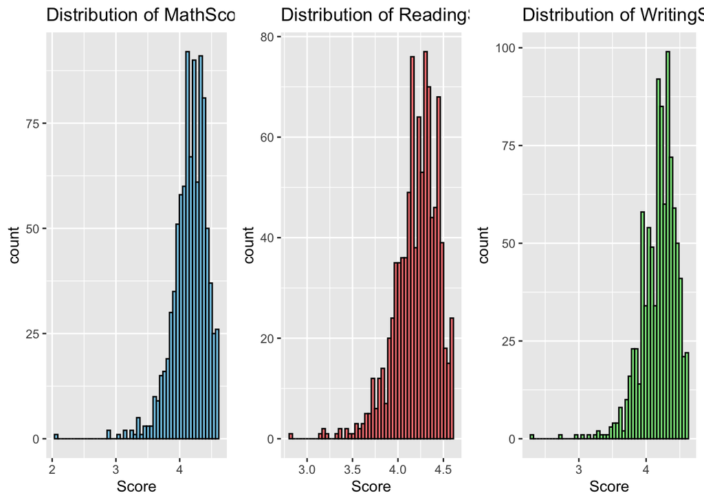

```r
# Create a ggplot for the distribution of MathScore
plot_math <- ggplot(data_cleaned, aes(x = ln_math)) +
  geom_histogram(fill = "skyblue", color = "black", bins = 50) +
  labs(title = "Distribution of MathScore", x = "Score")

# Create a ggplot for the distribution of ReadingScore
plot_reading <- ggplot(data_cleaned, aes(x = ln_reading)) +
  geom_histogram(fill = "lightcoral", color = "black", bins = 50) +
  labs(title = "Distribution of ReadingScore", x = "Score")

# Create a ggplot for the distribution of WritingScore
plot_writing <- ggplot(data_cleaned, aes(x = ln_writing)) +
  geom_histogram(fill = "lightgreen", color = "black", bins = 50) +
  labs(title = "Distribution of WritingScore", x = "Score")

grid.arrange(plot_math, plot_reading, plot_writing, ncol = 3)
```

```r
ggtitle("Distribution of the ln test scores")
```

```
## $title
## [1] "Distribution of the ln test scores"
##
## attr(,"class")
## [1] "labels"
```

Gender

- The distribution of male and female students in the dataset is fairly balanced.
- Score wise girls performed better that boys in ReadingScore andwritingScore, whereas boys scored better in MathScore.

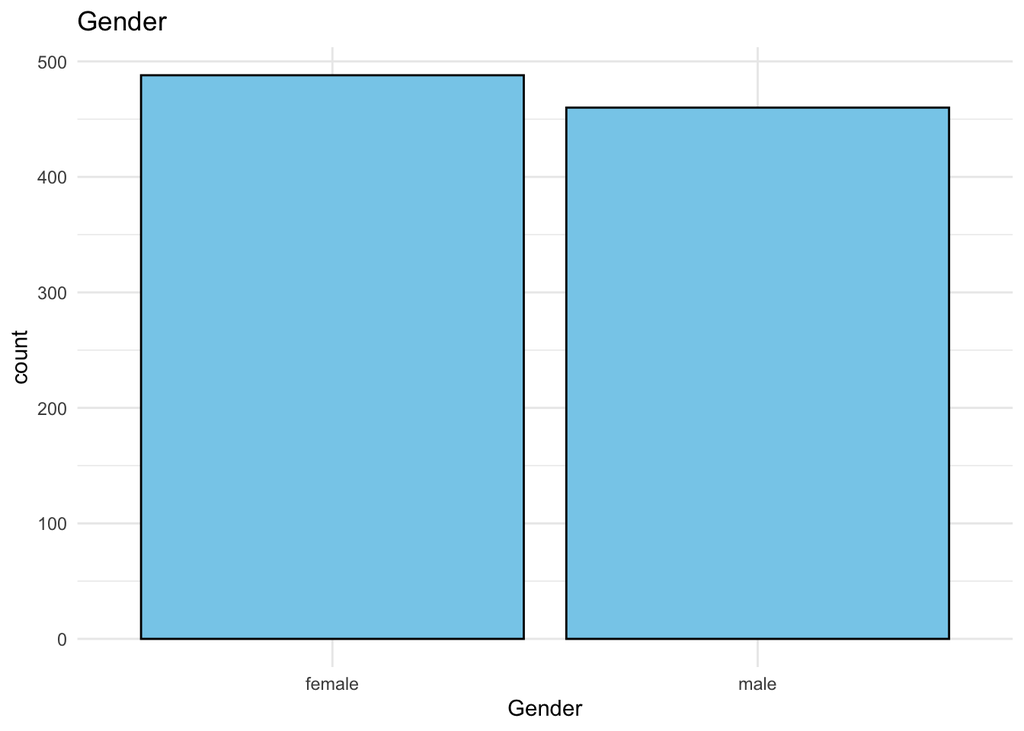

```r
ggplot(data_cleaned, aes(x = Gender)) +
  geom_bar(fill = "skyblue", color = "black") +
  labs(title = "Gender") +
  theme_minimal()
```

```r
mean_scores <- data_cleaned %>%
  group_by(Gender) %>%
  summarise(
    Mean_MathScore = mean(MathScore),
    Mean_ReadingScore = mean(ReadingScore),
    Mean_WritingScore = mean(WritingScore)
  )

print(mean_scores)
```

```
## # A tibble: 2 × 4
##   Gender Mean_MathScore Mean_ReadingScore Mean_WritingScore
##   <fct>           <dbl>             <dbl>             <dbl>
## 1 female           63.4              72.3              72.3
## 2 male             68.7              65.2              63.3
```

Parent(s) educational background

- There are six categories of educational background of parent(s) of the students, ranging from master’s education (the highest level) to highschool dropouts (some high school)
- In terms of distribution, master’s degree holder parent(s) are the least at 5.8% and parent(s) with some college are the most at 26.6%.
- When it comes to the students’ test scores, there seems to be a clear correlation with their parents(s) educational background. Children of highly educated parents score better than the children of less educated parents. This pattern is seen consistently with all three test subjects.

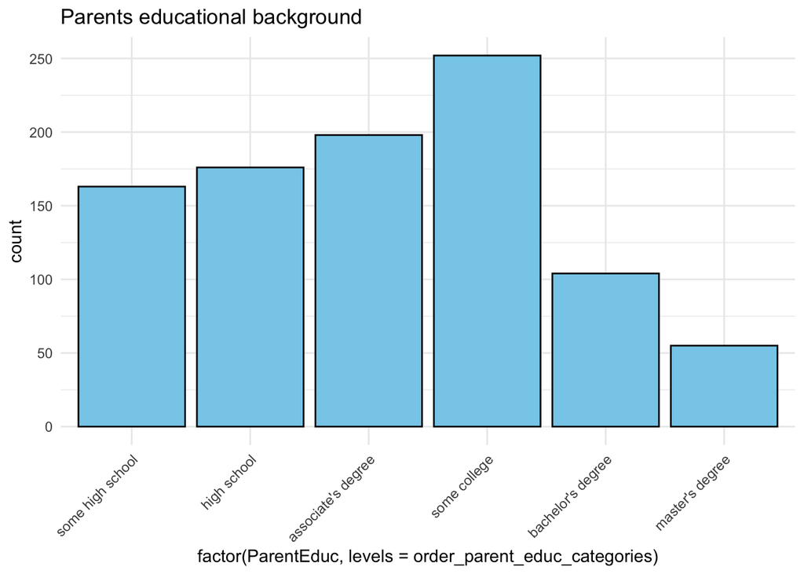

```r
order_parent_educ_categories <- c('some high school', 'high school', "associate's degree", 'some college', "bachelor's degree", "master's degree")

ggplot(data_cleaned, aes(x = factor(ParentEduc, levels = order_parent_educ_categories))) +
  geom_bar(fill = "skyblue", color = "black") +
  labs(title = "Parents educational background") +
  theme_minimal() +
  theme(axis.text.x = element_text(angle = 45, hjust = 1))  # Rotate x-axis labels
```

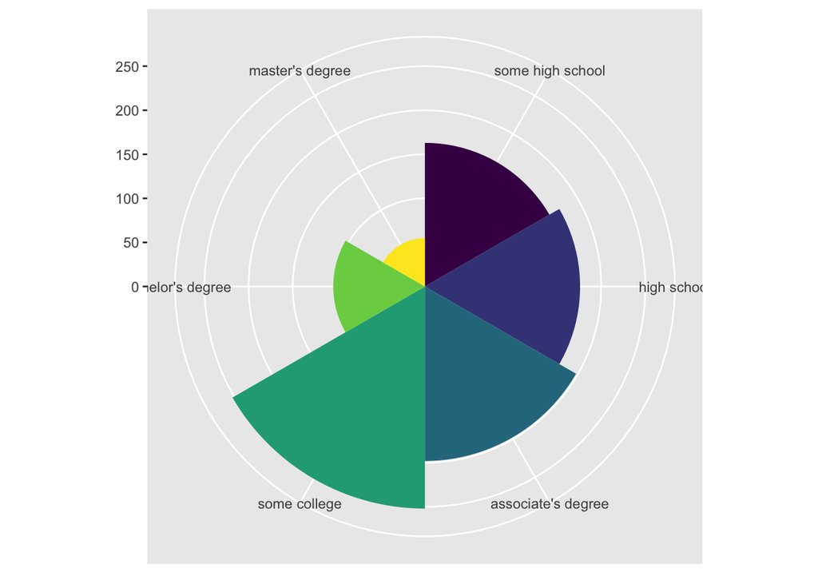

```r
bar_parent <- ggplot(data = data_cleaned) +
  geom_bar(
    mapping = aes(x = ParentEduc, fill = ParentEduc),
    show.legend = FALSE,
    width = 1
  ) +
  theme(aspect.ratio = 1) +
  labs(x = NULL, y = NULL)
bar_parent + coord_polar()
```

```r
val_cnt <- as.data.frame(table(data_cleaned$ParentEduc))
val_cnt_norm <- prop.table(table(data_cleaned$ParentEduc)) * 100

val_cnt
```

```
##                 Var1 Freq
## 1   some high school  163
## 2        high school  176
## 3 associate's degree  198
## 4       some college  252
## 5  bachelor's degree  104
## 6    master's degree   55
```

```r
val_cnt_norm <- as.data.frame(val_cnt_norm)
val_cnt_norm
```

```
##                 Var1      Freq
## 1   some high school 17.194093
## 2        high school 18.565401
## 3 associate's degree 20.886076
## 4       some college 26.582278
## 5  bachelor's degree 10.970464
## 6    master's degree  5.801688
```

```r
mean_score_summary <- data_cleaned%>%
  group_by(ParentEduc) %>%
  summarise_all(mean) %>%
  select(ParentEduc,MathScore, ReadingScore, WritingScore)
mean_score_summary
```

```
## # A tibble: 6 × 4
##   ParentEduc         MathScore ReadingScore WritingScore
##   <ord>                  <dbl>        <dbl>        <dbl>
## 1 some high school        63.1         66.7         64.8
## 2 high school             62.3         64.5         62.5
## 3 associate's degree      68.1         70.8         69.8
## 4 some college            66.6         68.5         68.2
## 5 bachelor's degree       69.5         72.9         73.3
## 6 master's degree         69.3         75.9         76.3
```

Ethnic group

- There are five races/ethnic groups represented in the dataset; (anonymized) from group A to group E
- With 35.4% of the student population, race group C are the most represented whereas with only 8.4% race group A are the least.
- The effect of race on students’ performance is clear to see. Race group E students are by far the better performers having scored 6 points more than the second group (D) in math and 3 more points in reading score and close to 1 point in writing test. At the other end of the scoreboard we find race group A; this group scored almost 12 points on math lower than that of group E.

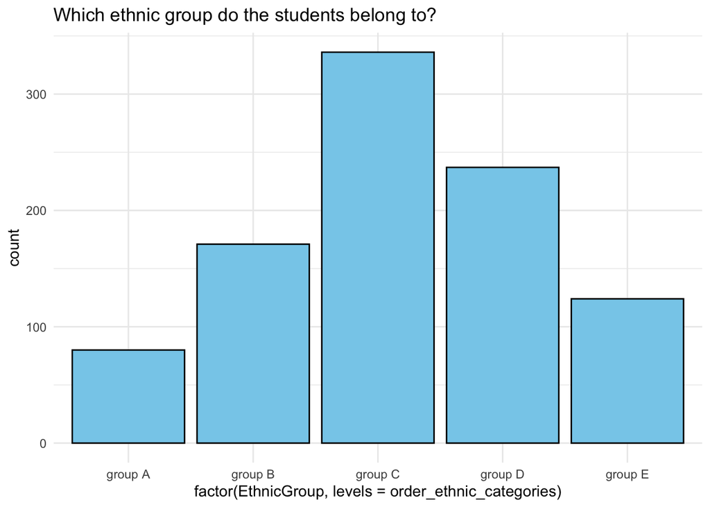

```r
order_ethnic_categories <- c('group A', 'group B', 'group C', 'group D', 'group E')

ggplot(data_cleaned, aes(x = factor(EthnicGroup, levels = order_ethnic_categories))) +
  geom_bar(fill = "skyblue", color = "black") +
  labs(title = "Which ethnic group do the students belong to?") +
  theme_minimal()
```

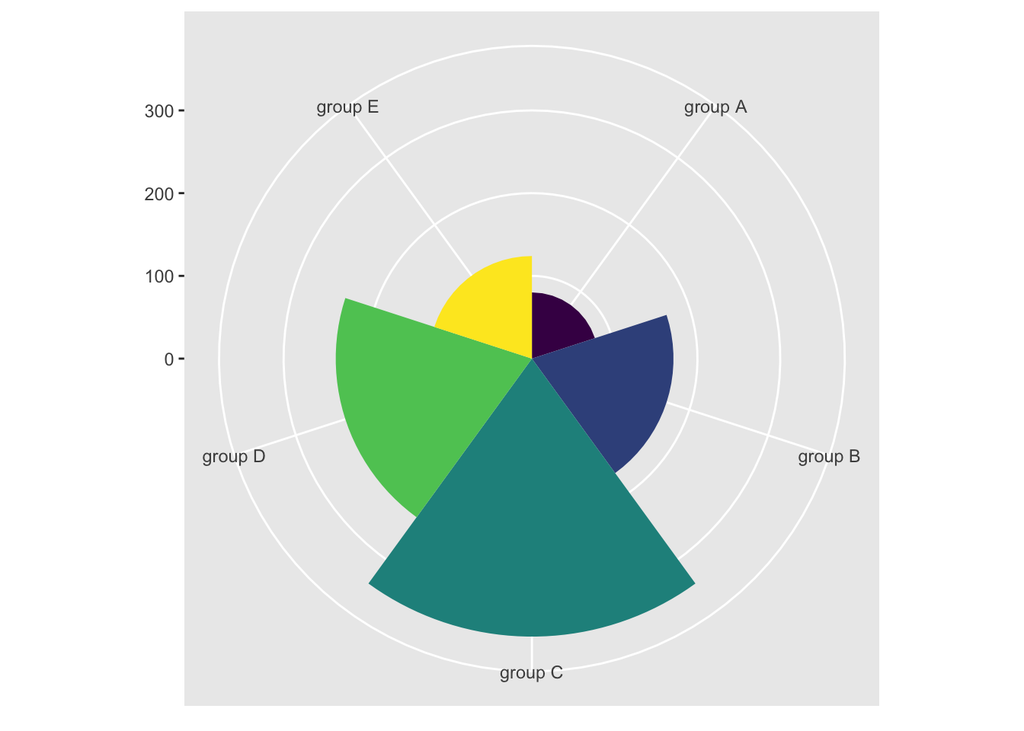

```r
bar_parent <- ggplot(data = data_cleaned) +
  geom_bar(
    mapping = aes(x = EthnicGroup, fill = EthnicGroup),
    show.legend = FALSE,
    width = 1
  ) +
  theme(aspect.ratio = 1) +
  labs(x = NULL, y = NULL)
bar_parent + coord_polar()
```

```r
val_cnt <- as.data.frame(table(data_cleaned$EthnicGroup))
val_cnt_norm <- prop.table(table(data_cleaned$EthnicGroup)) * 100

val_cnt
```

```
##      Var1 Freq
## 1 group A   80
## 2 group B  171
## 3 group C  336
## 4 group D  237
## 5 group E  124
```

```r
val_cnt_norm <- as.data.frame(val_cnt_norm)
val_cnt_norm
```

```
##      Var1      Freq
## 1 group A  8.438819
## 2 group B 18.037975
## 3 group C 35.443038
## 4 group D 25.000000
## 5 group E 13.080169
```

```r
mean_score_summary <- data_cleaned%>%
  group_by(EthnicGroup) %>%
  summarise_all(mean) %>%
  select(EthnicGroup ,MathScore, ReadingScore, WritingScore)
mean_score_summary
```

```
## # A tibble: 5 × 4
##   EthnicGroup MathScore ReadingScore WritingScore
##   <ord>           <dbl>        <dbl>        <dbl>
## 1 group A          62.2         65.3         63.4
## 2 group B          63.3         67.0         65.3
## 3 group C          64.2         68.2         67.1
## 4 group D          67.5         70.1         70.5
## 5 group E          73.9         73.2         71.7
```

Finding the correlation matrix between math, reading and writing scores.

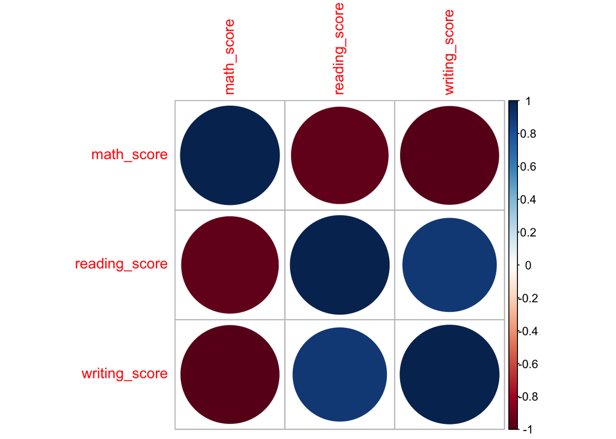

```r
scores_corr <-
  data_cleaned %>%
  select(MathScore, ReadingScore, WritingScore) %>%
  data.frame() %>%
  janitor:: clean_names()
cor.matrix<-cor(cor(scores_corr, use="pairwise.complete.obs"))
corrplot(cor.matrix)
```

Lunch Type:

- We notice that the amount of students on standard lunch is greater than the amount of student on free and reduced.
- We can see that those on standard lunch have a higher correlation to having a higher mean score on all 3 sections of the test.

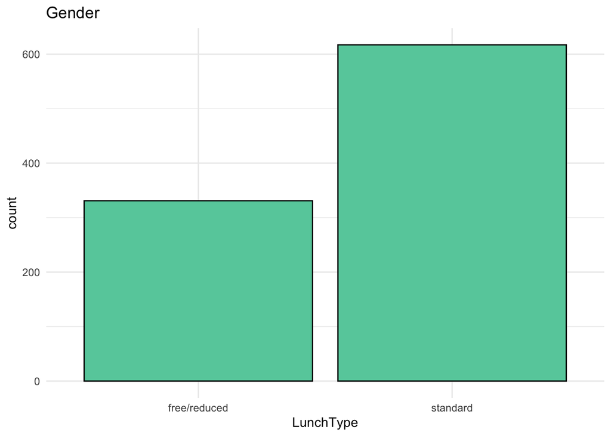

```r
ggplot(data_cleaned, aes(x = LunchType)) +
  geom_bar(fill = "aquamarine3", color = "black") +
  labs(title = "Gender") +
  theme_minimal()
```

```r
mean_scores_lunch <- data_cleaned %>%
  group_by(LunchType) %>%
  summarise(
    Mean_MathScore = mean(MathScore),
    Mean_ReadingScore = mean(ReadingScore),
    Mean_WritingScore = mean(WritingScore)
  )
mean_scores_lunch
```

```
## # A tibble: 2 × 4
##   LunchType    Mean_MathScore Mean_ReadingScore Mean_WritingScore
##   <chr>                 <dbl>             <dbl>             <dbl>
## 1 free/reduced           58.5              64.1              62.7
## 2 standard               70.0              71.4              70.7
```

Test Prep:

- More people did not study for the test than those who did
- Those who did complete test prep have a higher mean in scores than those who didnt.
- Associated with those who did not complete test prep could be bringing down the standard mean even further.

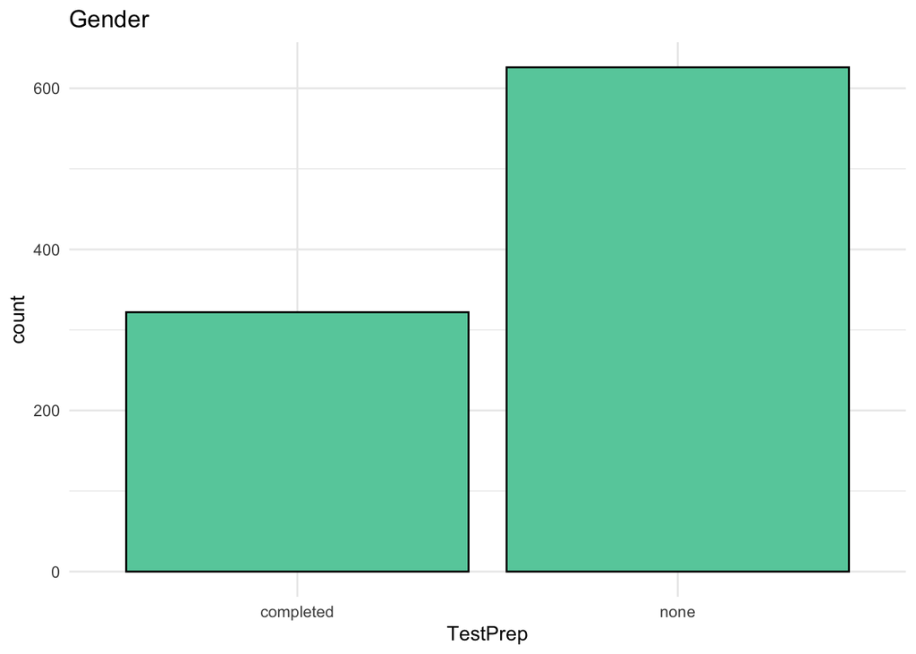

```r
ggplot(data_cleaned, aes(x = TestPrep)) +
  geom_bar(fill = "aquamarine3", color = "black") +
  labs(title = "Gender") +
  theme_minimal()
```

```r
mean_scores_prep <- data_cleaned %>%
  group_by(TestPrep) %>%
  summarise(
    Mean_MathScore = mean(MathScore),
    Mean_ReadingScore = mean(ReadingScore),
    Mean_WritingScore = mean(WritingScore)
  )
mean_scores_prep
```

```
## # A tibble: 2 × 4
##   TestPrep  Mean_MathScore Mean_ReadingScore Mean_WritingScore
##   <chr>              <dbl>             <dbl>             <dbl>
## 1 completed           70.0              73.5              74.3
## 2 none                63.9              66.4              64.7
```

Parent Marital Status:

- Most parents seen are married within this school.
- Surprisingly those parents who are widowded and married had very similar test scores among the participants.

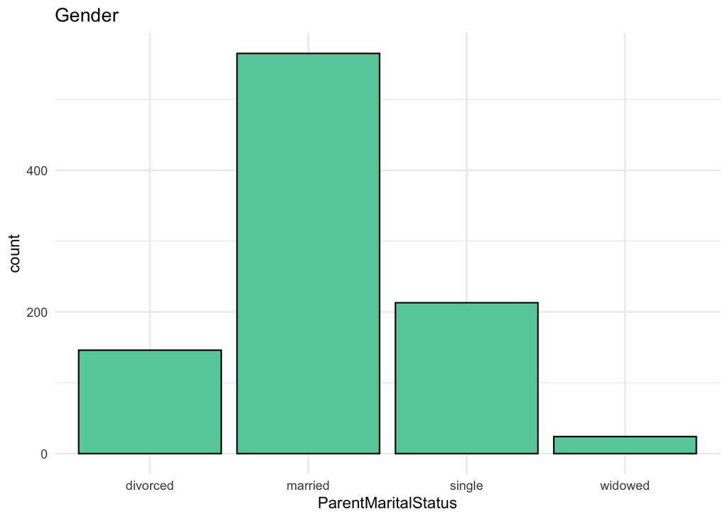

```r
ggplot(data_cleaned, aes(x = ParentMaritalStatus)) +
  geom_bar(fill = "aquamarine3", color = "black") +
  labs(title = "Gender") +
  theme_minimal()
```

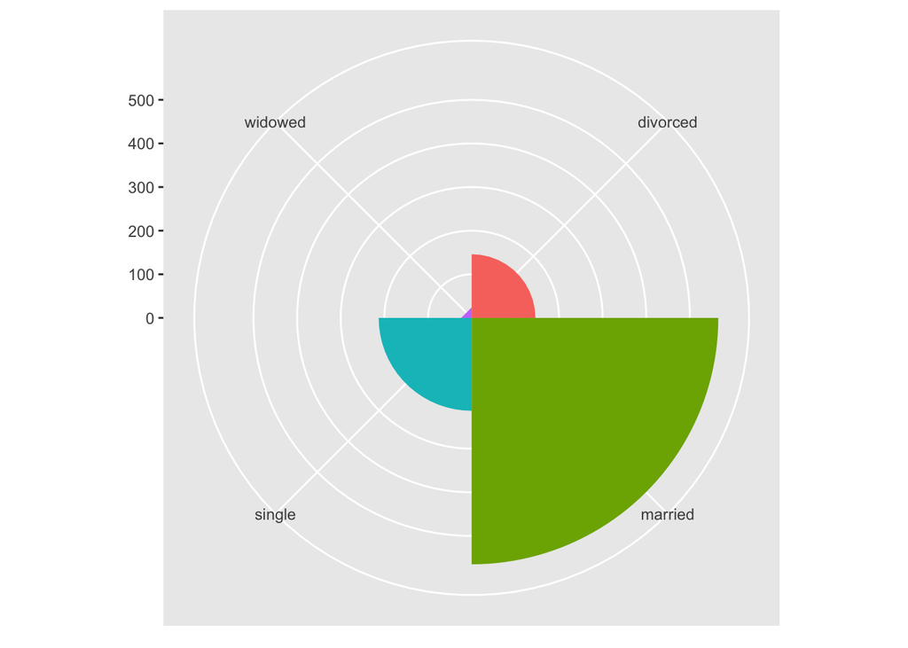

```r
bar_status <- ggplot(data = data_cleaned) +
  geom_bar(
    mapping = aes(x = ParentMaritalStatus, fill = ParentMaritalStatus),
    show.legend = FALSE,
    width = 1
  ) +
  theme(aspect.ratio = 1) +
  labs(x = NULL, y = NULL)
bar_status + coord_polar()
```

```r
mean_scores_prep <- data_cleaned %>%
  group_by(ParentMaritalStatus) %>%
  summarise(
    Mean_MathScore = mean(MathScore),
    Mean_ReadingScore = mean(ReadingScore),
    Mean_WritingScore = mean(WritingScore)
  )
mean_scores_prep
```

```
## # A tibble: 4 × 4
##   ParentMaritalStatus Mean_MathScore Mean_ReadingScore Mean_WritingScore
##   <chr>                        <dbl>             <dbl>             <dbl>
## 1 divorced                      63.1              66.0              65
## 2 married                       67.3              69.9              69.0
## 3 single                        64.3              67.7              66.9
## 4 widowed                       68.2              70.5              69.3
```

Practice Sport:

- More people play sports regularly or sometimes more than people who dont.
- It appears to not have a massive affect on the outcome of the test scores

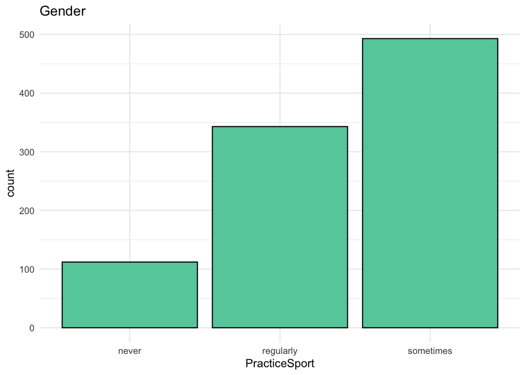

```r
ggplot(data_cleaned, aes(x = PracticeSport)) +
  geom_bar(fill = "aquamarine3", color = "black") +
  labs(title = "Gender") +
  theme_minimal()
```

```r
mean_scores_prep <- data_cleaned %>%
  group_by(PracticeSport) %>%
  summarise(
    Mean_MathScore = mean(MathScore),
    Mean_ReadingScore = mean(ReadingScore),
    Mean_WritingScore = mean(WritingScore)
  )
mean_scores_prep
```

```
## # A tibble: 3 × 4
##   PracticeSport Mean_MathScore Mean_ReadingScore Mean_WritingScore
##   <chr>                  <dbl>             <dbl>             <dbl>
## 1 never                   64.9              69.0              66.6
## 2 regularly               66.6              68.4              68.2
## 3 sometimes               65.8              69.1              68.1
```

Is First Child:

- We can see that most students are first children in their family
- On average first children do better on the test then those who arent may be based on how much they are able to study.

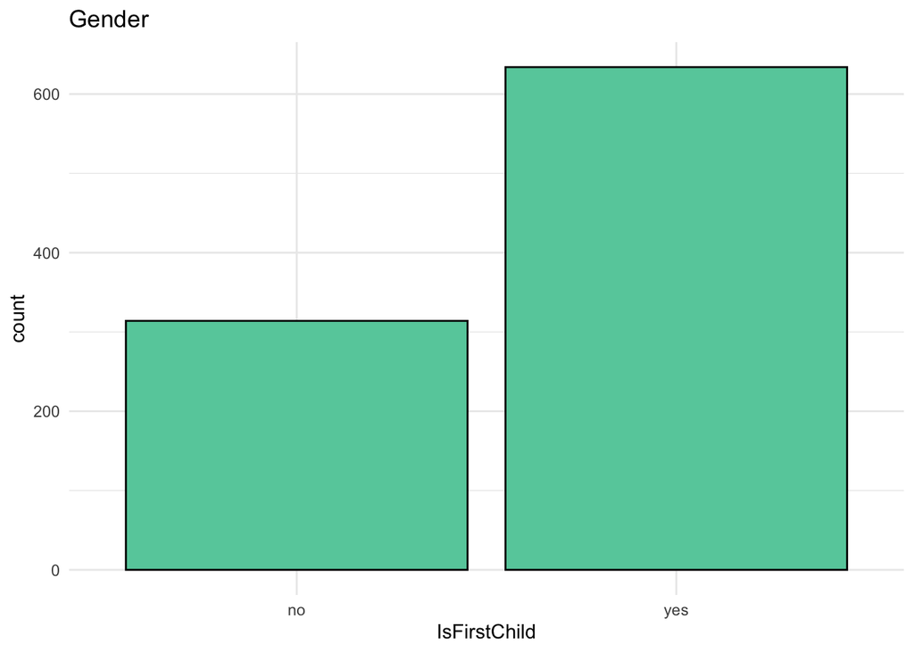

```r
ggplot(data_cleaned, aes(x = IsFirstChild)) +
  geom_bar(fill = "aquamarine3", color = "black") +
  labs(title = "Gender") +
  theme_minimal()
```

```r
mean_scores_prep <- data_cleaned %>%
  group_by(IsFirstChild) %>%
  summarise(
    Mean_MathScore = mean(MathScore),
    Mean_ReadingScore = mean(ReadingScore),
    Mean_WritingScore = mean(WritingScore)
  )
mean_scores_prep
```

```
## # A tibble: 2 × 4
##   IsFirstChild Mean_MathScore Mean_ReadingScore Mean_WritingScore
##   <chr>                 <dbl>             <dbl>             <dbl>
## 1 no                     64.6              67.0              66.2
## 2 yes                    66.7              69.8              68.8
```

Number of siblings:

-most people only have a few siblings

- since those with many siblings are a smaller proportion of the population, the data may be skewed based on that one significant persons intelligence/performance on test

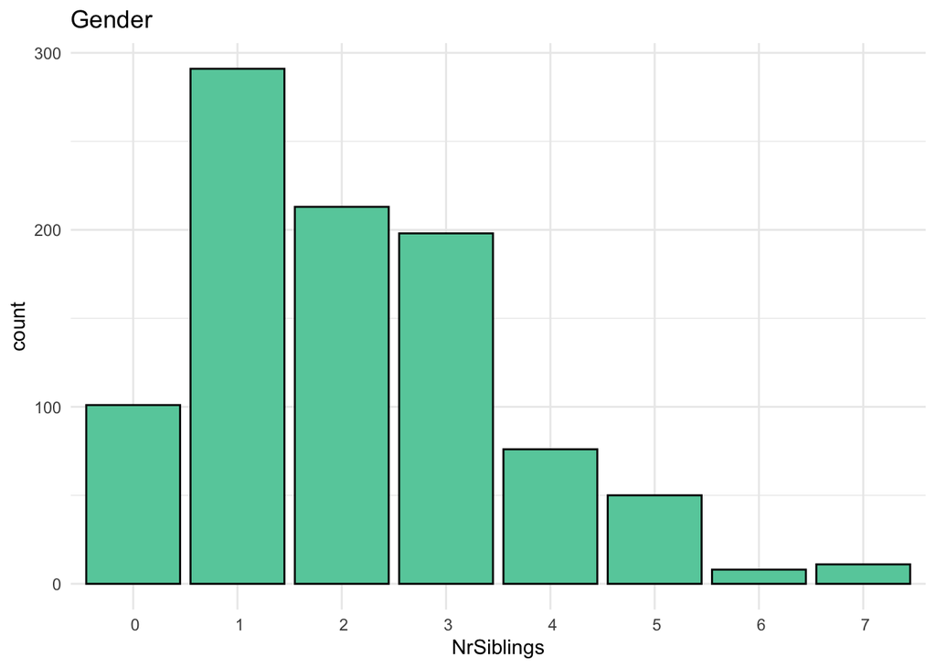

```r
ggplot(data_cleaned, aes(x = NrSiblings)) +
  geom_bar(fill = "aquamarine3", color = "black") +
  labs(title = "Gender") +
  theme_minimal()
```

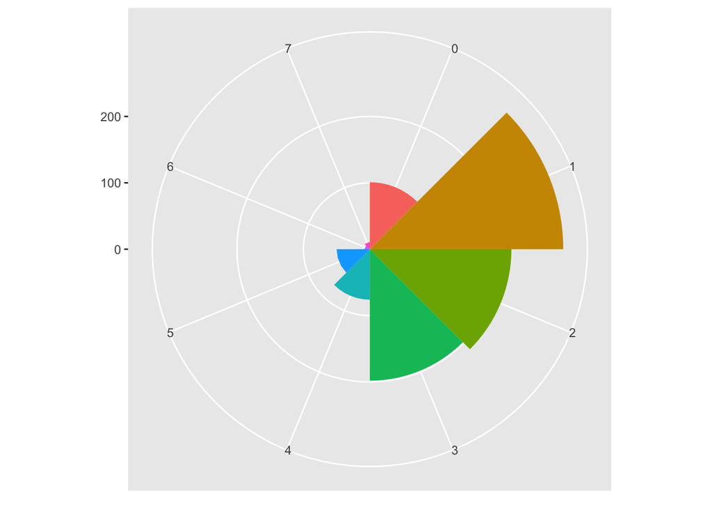

```r
bar_numb <- ggplot(data = data_cleaned) +
  geom_bar(
    mapping = aes(x = NrSiblings, fill = NrSiblings),
    show.legend = FALSE,
    width = 1
  ) +
  theme(aspect.ratio = 1) +
  labs(x = NULL, y = NULL)
bar_numb + coord_polar()
```

```r
mean_scores_prep <- data_cleaned %>%
  group_by(NrSiblings) %>%
  summarise(
    Mean_MathScore = mean(MathScore),
    Mean_ReadingScore = mean(ReadingScore),
    Mean_WritingScore = mean(WritingScore)
  )
mean_scores_prep
```

```
## # A tibble: 8 × 4
##   NrSiblings Mean_MathScore Mean_ReadingScore Mean_WritingScore
##   <chr>               <dbl>             <dbl>             <dbl>
## 1 " 0"                 68.7              69.1              68.4
## 2 " 1"                 65.0              69.3              68.0
## 3 " 2"                 64.8              67.7              66.6
## 4 " 3"                 66.8              69.2              68.7
## 5 " 4"                 67.6              70.9              70.3
## 6 " 5"                 64.2              65.8              64.7
## 7 " 6"                 67.9              70.1              71.9
## 8 " 7"                 70.6              68.7              68.5
```

Transport Means:

- most people take the school bus
- no direct correlation on scores based on private versus public transit

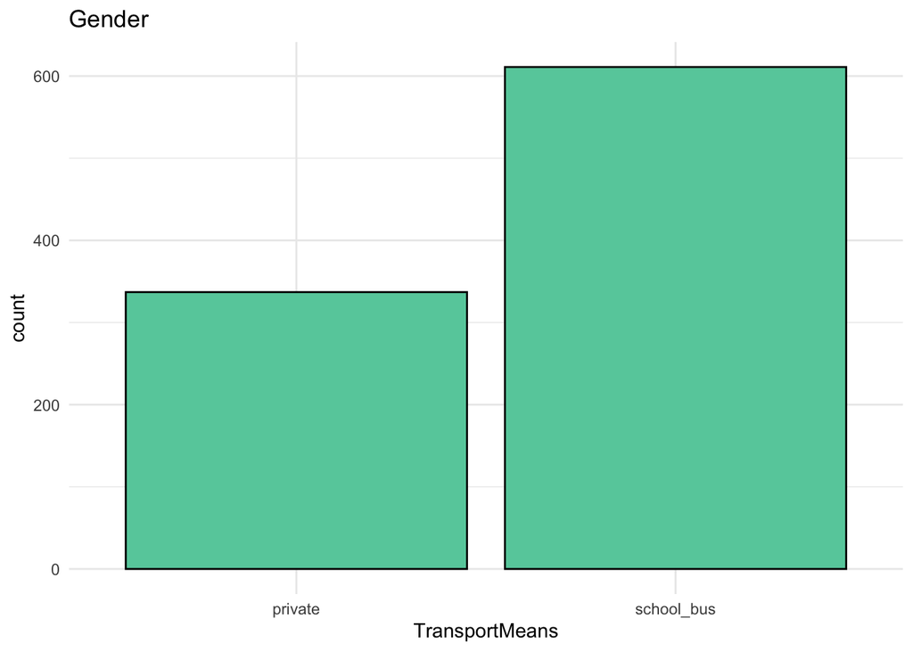

```r
ggplot(data_cleaned, aes(x = TransportMeans)) +
  geom_bar(fill = "aquamarine3", color = "black") +
  labs(title = "Gender") +
  theme_minimal()
```

```r
mean_scores_Trans <- data_cleaned %>%
  group_by(TransportMeans) %>%
  summarise(
    Mean_MathScore = mean(MathScore),
    Mean_ReadingScore = mean(ReadingScore),
    Mean_WritingScore = mean(WritingScore)
  )
mean_scores_Trans
```

```
## # A tibble: 2 × 4
##   TransportMeans Mean_MathScore Mean_ReadingScore Mean_WritingScore
##   <chr>                   <dbl>             <dbl>             <dbl>
## 1 private                  65.6              68.0              67.3
## 2 school_bus               66.2              69.3              68.3
```

Weekly Study Hours:

- Most people wanted to study between 5- 10 hours
- No significant affect on if you study more than 10 hours compared to people who study between 5-10 hours

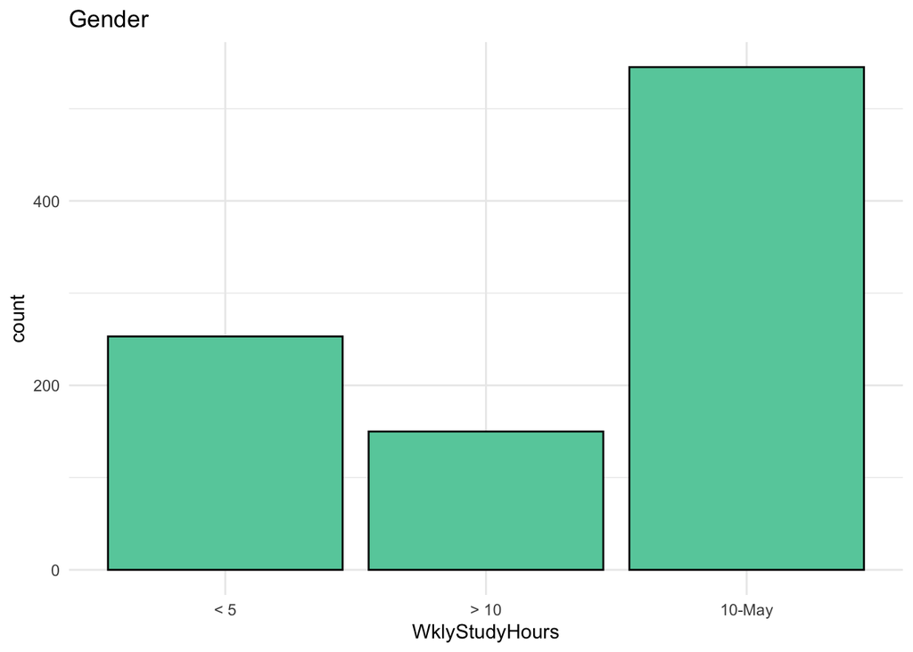

```r
ggplot(data_cleaned, aes(x = WklyStudyHours)) +
  geom_bar(fill = "aquamarine3", color = "black") +
  labs(title = "Gender") +
  theme_minimal()
```

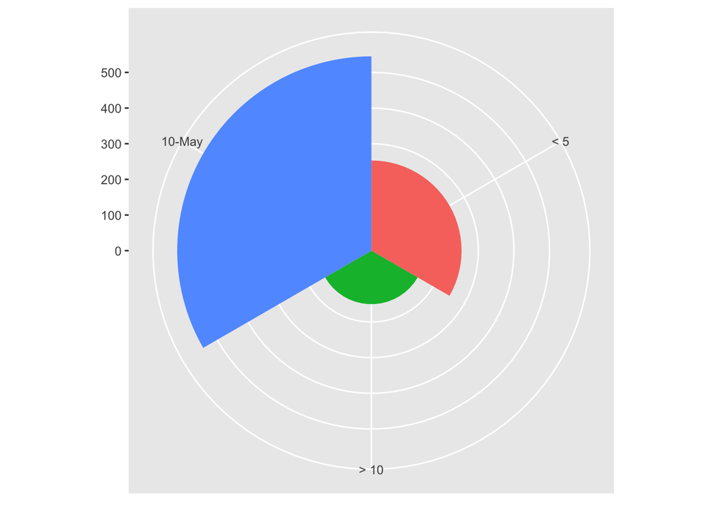

```r
bar_study <- ggplot(data = data_cleaned) +
  geom_bar(
    mapping = aes(x = WklyStudyHours, fill = WklyStudyHours),
    show.legend = FALSE,
    width = 1
  ) +
  theme(aspect.ratio = 1) +
  labs(x = NULL, y = NULL)
bar_study + coord_polar()
```

```r
mean_scores_study <- data_cleaned %>%
  group_by(WklyStudyHours) %>%
  summarise(
    Mean_MathScore = mean(MathScore),
    Mean_ReadingScore = mean(ReadingScore),
    Mean_WritingScore = mean(WritingScore)
  )
mean_scores_study
```

```
## # A tibble: 3 × 4
##   WklyStudyHours Mean_MathScore Mean_ReadingScore Mean_WritingScore
##   <chr>                   <dbl>             <dbl>             <dbl>
## 1 10-May                   66.8              69.5              68.6
## 2 < 5                      63.0              66.9              65.9
## 3 > 10                     68                69.8              69.0
```